# Practical Machine Learning, Course Project

Monika

# Background

Using devices such as Jawbone Up, Nike FuelBand, and Fitbit it is now possible to collect a large amount of data about personal activity relatively inexpensively. These type of devices are part of the quantified self movement – a group of enthusiasts who take measurements about themselves regularly to improve their health, to find patterns in their behavior, or because they are tech geeks. One thing that people regularly do is quantify how much of a particular activity they do, but they rarely quantify how well they do it. In this project, your goal will be to use data from accelerometers on the belt, forearm, arm, and dumbell of 6 participants. They were asked to perform barbell lifts correctly and incorrectly in 5 different ways. More information is available from the website here: http://groupware.les.inf.puc-rio.br/har (see the section on the Weight Lifting Exercise Dataset).

# Data

Data is downloaded into local files - there are two sets of data, the training set and the testing set. I will use the testing set to perform the predictions from the final model on. When manually checking the data I noticed ‘#DIV/0!’ value in numeric data, which I transformed into NA values.

```r
library(caret, quietly=TRUE)
#download.file(url = 'https://d396qusza40orc.cloudfront.net/predmachlearn/pml-training.csv',
#               destfile = 'train.csv')
#download.file(url = 'https://d396qusza40orc.cloudfront.net/predmachlearn/pml-testing.csv',
#               destfile = 'test.csv')
train <- read.csv(file = 'train.csv', na.strings = c('NA','#DIV/0!',''))
test <- read.csv(file = 'test.csv', na.strings = c('NA','#DIV/0!',''))
```

During exploratory data analysis I noticed that the first 7 columns of the data are dimensional, and may not be pertinent to the prediction model. The balance of the fields are numeric according to the data documentation available here: http://groupware.les.inf.puc-rio.br/har. The balance of the columns are looped through and cast into numeric data with the exception of the last column, which is the categorical class the prediction model will classify for. I perform the same procedure on training and testing data.

```r
for(i in c(8:ncol(train)-1)) {
  train[,i] = as.numeric(as.character(train[,i]))
  test[,i] = as.numeric(as.character(test[,i]))
}
```

Analysis also revealed that several of the many variables are very sparse and thus may not be as useful for building a classification model. The following code initiates a slicer index of column names without the columns with NA values and also removes the inital seven columns of dimensional data. Rather than modify the actual data, this vector of column names will be used as a slicer index into the training data, cross-validation data, and the testing data when interacting with a model.

```r
feature_index <- colnames(train[colSums(is.na(train)) == 0])
feature_index <- feature_index[-c(1:7)]
```

# Cross-Validation

```r
set.seed(42)
index_train <- createDataPartition(y=train$classe, p=0.70, list=FALSE)
train1 <- train[index_train,feature_index]
test1 <- train[-index_train,feature_index]
dim(train1); dim(test1)
```

```
## [1] 13737    53
```

```
## [1] 5885   53
```

# Pre-Model Fitting

Before a model is fit it is useful to have an idea of the ratio that should be expected of the classification variable outcome. This wil govern how we seek to optimize models for specificity, sensitivity, and positive/negative predictive value.

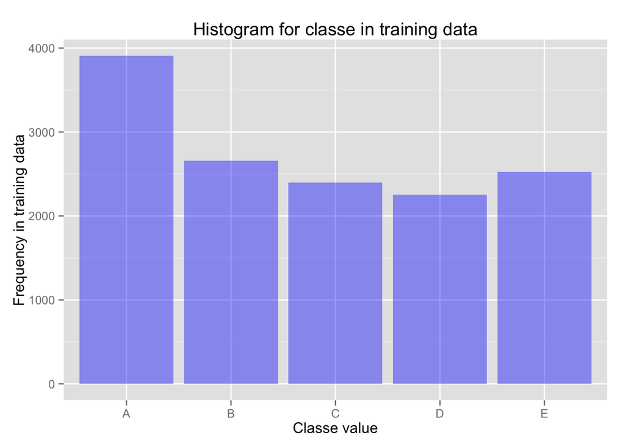

```r
library(ggplot2)
qplot(train1$classe, geom="histogram", main = "Histogram for classe in training data",
      xlab = "Classe value", ylab = 'Frequency in training data',
      fill=I("blue"), alpha=I(.4))
```

I selected a random forest from the preliminary analysis. For each candidate model, predictions are made agaist the cross-validation data set. Then, a confusion matrix is calculated and stored for each model for later reference.

```r
model <- train(classe ~ ., data = train1, method = 'rf',
                trControl = trainControl(method = "cv",
                                         number = 4,
                                         allowParallel = TRUE,
                                         verboseIter = TRUE))
prediction <- predict(model, test1)
cm <- confusionMatrix(prediction, test1$classe)
cm
```

```
## Confusion Matrix and Statistics
##
##           Reference
## Prediction    A    B    C    D    E
##          A 1673    7    0    0    0
##          B    1 1132    8    0    0
##          C    0    0 1017   18    0
##          D    0    0    1  946    0
##          E    0    0    0    0 1082
##
## Overall Statistics
##
##                Accuracy : 0.9941
##                  95% CI : (0.9917, 0.9959)
##     No Information Rate : 0.2845
##     P-Value [Acc > NIR] : < 2.2e-16
##
##                   Kappa : 0.9925
##  Mcnemar's Test P-Value : NA
##
## Statistics by Class:
##
##                      Class: A Class: B Class: C Class: D Class: E
## Sensitivity            0.9994   0.9939   0.9912   0.9813   1.0000
## Specificity            0.9983   0.9981   0.9963   0.9998   1.0000
## Pos Pred Value         0.9958   0.9921   0.9826   0.9989   1.0000
## Neg Pred Value         0.9998   0.9985   0.9981   0.9964   1.0000
## Prevalence             0.2845   0.1935   0.1743   0.1638   0.1839
## Detection Rate         0.2843   0.1924   0.1728   0.1607   0.1839
## Detection Prevalence   0.2855   0.1939   0.1759   0.1609   0.1839
## Balanced Accuracy      0.9989   0.9960   0.9938   0.9906   1.0000
```

# Predicting on test data

For the test results there are 20 samples asked to be classified. The column names are not consistent between the test and training data. It is necessary to rename the last column in the testing set for compatability. However, since that column will not be used in the model feature set being fed into the predictor the column name change unaffects the predictions. Once the predictions are made from the selected random forest model the prediction vector is shown.

```r
final_cols <- length(colnames(test[]))
colnames(test)[final_cols] <- 'classe'
quiz <- predict(model, test[,feature_index])
quiz
```

```
##  [1] B A B A A E D B A A B C B A E E A B B B
## Levels: A B C D E
```